# gene length biases

```
## Loading GOcategoryStats
```

```
## [[1]]
## <environment: namespace:GOcategoryStats>
```

Generate lists of mouse genes by length.

## Pre-processing of data

See closest_gene.Rmd - the generation of the genfo file was the same. We can use the genfo file created from that processing to generate the biased gene lists.

It can also be imported in to the R session so that we can plot the gene length distribution for all genes in the Mus_musculus.GRCm38.94.gtf.gz genome.

### Check lengths of genes

#### Plot out the length distribution for all the genes in Mus_musculus.GRCm38.94

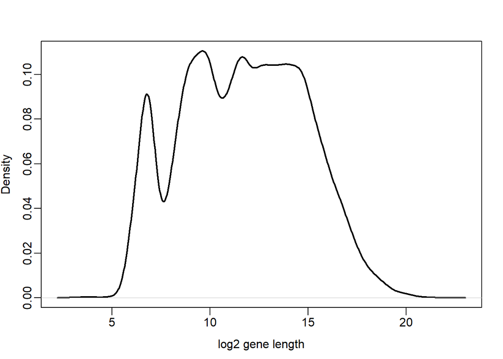

#### Select gene length thresholds.

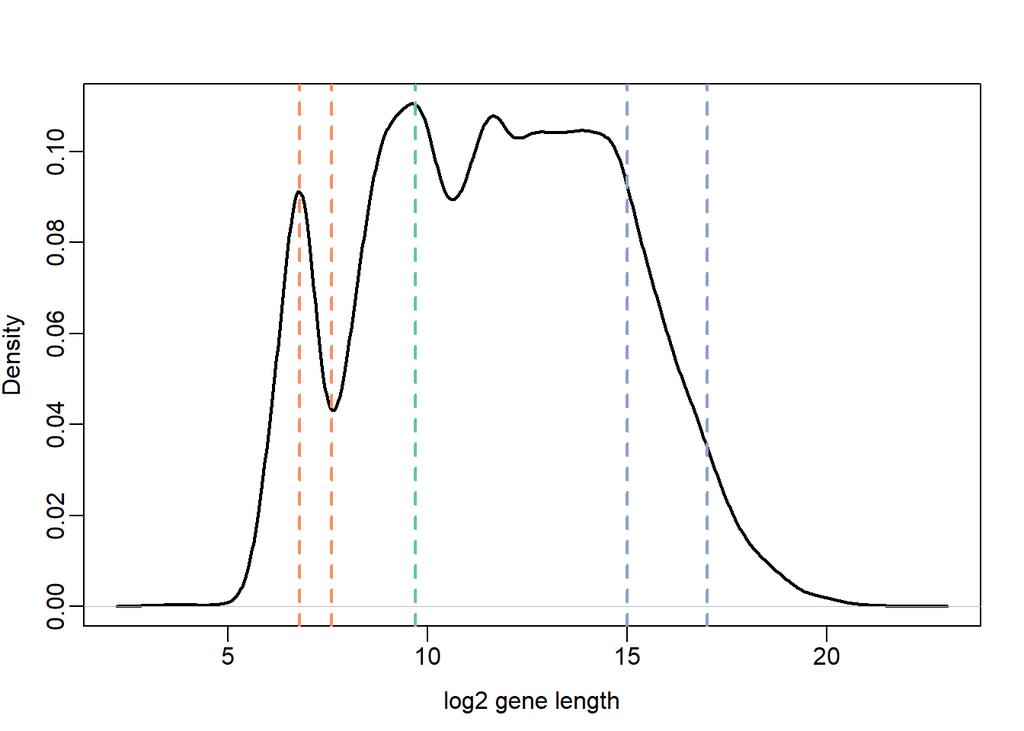

The number of genes that remain after filtering for each length category.

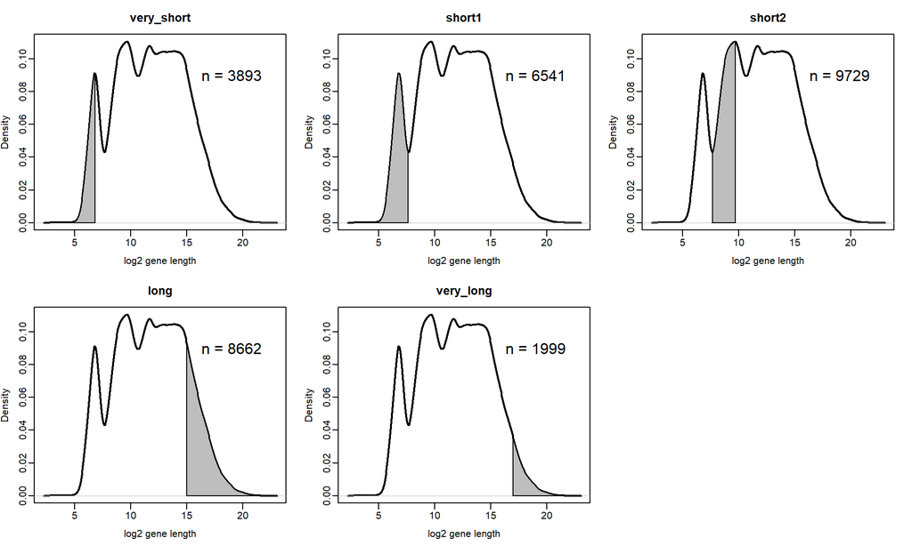

### Further pre-processing: Generating the biased gene lists

### Generating the biased gene lists within R

Check they all look right

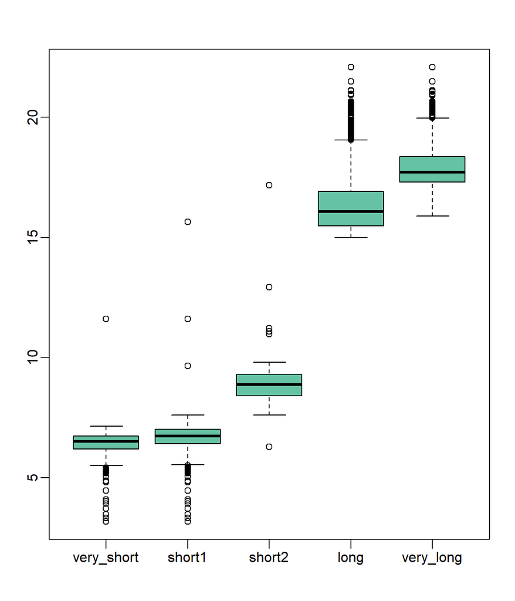

The odd gene that doesn’t fall within the expected size range may be due to name duplication.

### GO overrepresentation analysis

Run the gene lists through a GO overrepresentation analysis.

We don’t want to run the GO analysis each time the document is knitted as it takes too long. The code was run once and the data saved as an .rda object that can be quickly loaded in to the R session.

See how many significant categories were returned.

```
## [1] "length_results"
```

The number of gene sets that returned significant results from the GO overrepresentation analysis

```
## very_short     short1     short2       long  very_long
##         91         48         12        100        100
```

The bean plots show the number of categories returned from each gene list. The null results have been removed.

```
## log="y" selected
```

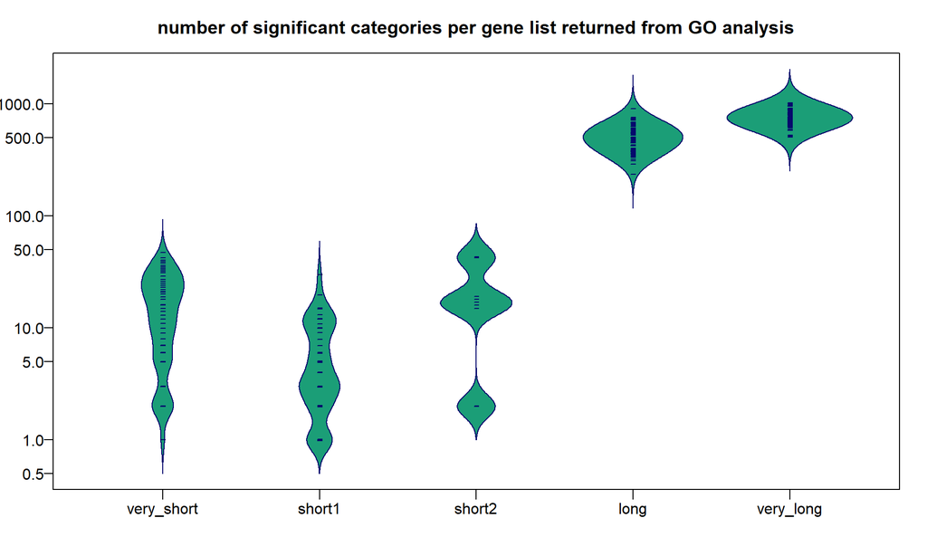

There are loads of results returned for the long genes, we’ll plot out the p and q values.

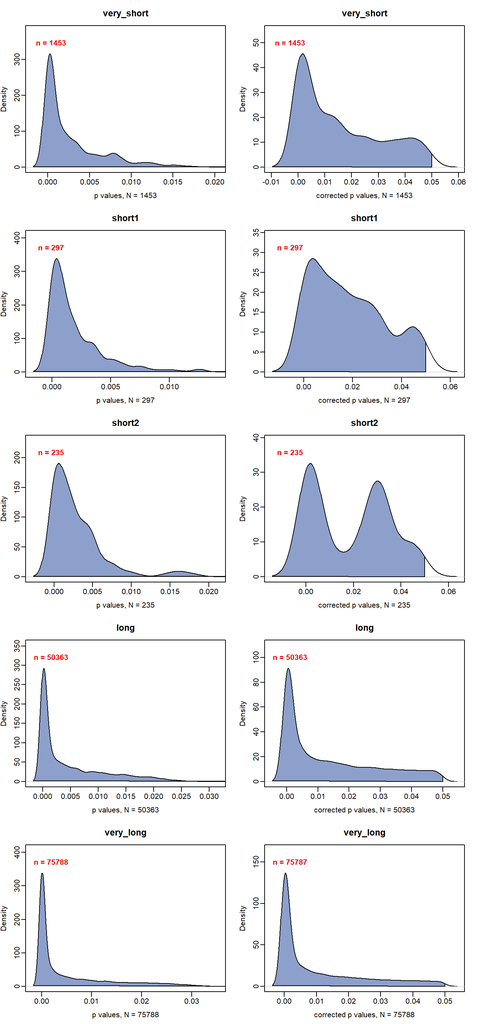

Plot how many times a category appeared.

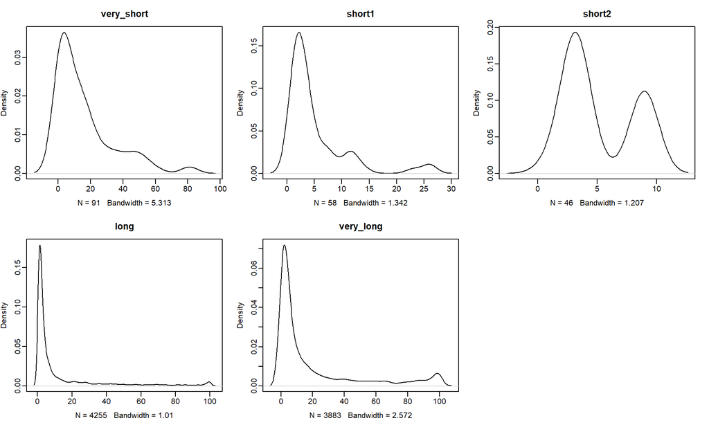

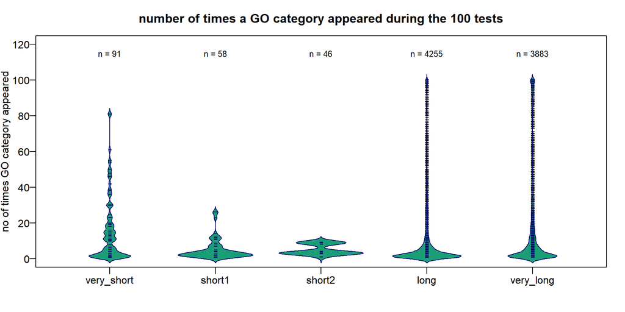

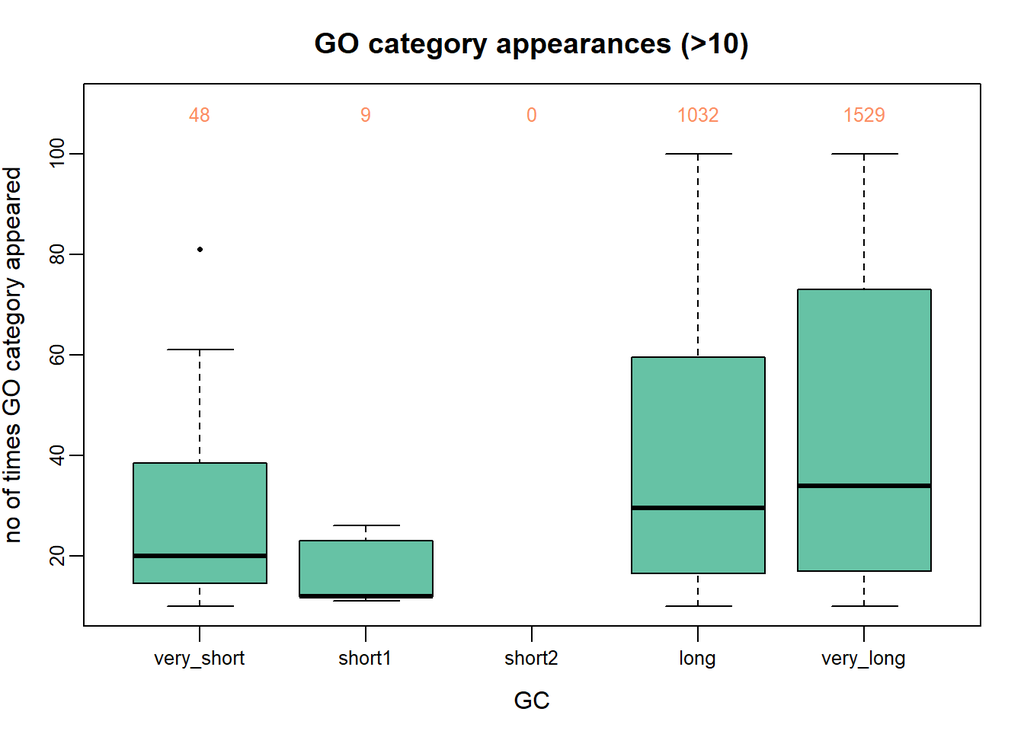

Replot just showing the data for categories that appeared >= 10 times

Create a dataset that contains these suspect set of categories

```
## very_short     short1     short2       long  very_long
##         48          9          0       1032       1529
```

```
## [1] 9
## [1] 0
## [1] 0
## [1] 919
## [1] 113
```

```
## [1] 113
```

All of the categories in the short1 category are found in the very short category so these can be reduced to one category. The short2 set do not overlap and can just be renamed to “short”

The very_long and long categories have a lot of overlapping categories so I’ll remove any from the long category that are found in the very_long category.

```
## very_short     short1     short2       long  very_long
##         48          0          0        113       1529
```

```
## very_short       long  very_long
##         48        113       1529
```